# Adventures in R: Session 3

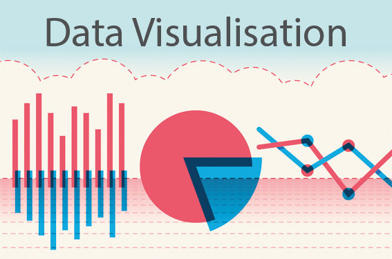

```r
1+3
```

Add a new chunk by navigating to *Insert >> Insert New R Chunk* in the toolbar or by pressing *Cmd+Option+I* (Mac).

You can *Knit* your document to pdf and Word too.

# 1 This Morning’s Session

This session focuses on data visualisation and manipulation in R. Today, we’re going to be analysing data from three different datasets. The session will cover:

- Cleaning and manipulating our data to make it more manageable
- Making data summary tables
- How to create different types of plots using base R and ‘tidyverse’ commands

## 1.1 Packages

The first thing we want to do before we start is load in the relevant packages for today. We’ll be using commands from the ‘dplyr’ (for data cleaning/manipulation) and ‘ggplot2’ (for plotting) packages. As ‘dplyr’ and ‘ggplot2’ commands are included in the ‘tidyverse’ package, that’s what we’re going to load in. The following code should do the job:

```r
## LOAD PACKAGES ####
library(tidyverse)
```

You might see some messages, but that is fine.

However, if this doesn’t work, you may need to install the packages. You only have to install a package once, but you have load a package in (like we just did above) every time you open R. To install a package for the first time, you can go to ** tools > install packages… >** and then search for the name of the package. You can also run it directly through the console by inputting `install.packages("tidyverse")`.

# 2 Categorical data

First, we’ll be using some data from a dialect questionnaire. This data can be found in the **data** folder, which is a folder within the current R Markdown folder. That means we can easily load it in without having to specify the full path (i.e. location) of the document. Try pressing play on the chunk below to read in the data:

```r
## LOAD IN DATA ####
dialect_data <- read.csv("dialectdata.csv")
```

We have called our dataset `dialect_data` and we should now be able to see it in the right corner panel under **Environment** as one of the things we have loaded in.

## 2.1 Exploring Our Data

Before we start manipulating or plotting, it’s a good idea to first view and explore our data in R.

How big is our ‘dialect_data’ dataset?

```r
dim(dialect_data)
```

This shows us how many rows and columns our data has.

Let’s have a look at the top six rows:

```r
head(dialect_data)
```

How about the bottom six?

```r
tail(dialect_data)
```

What are the names of the columns?

```r
colnames(dialect_data)
```

Note that the column names all have lower case titles. R does not treat uppercase and lower case the same! This is the advice given by Hadley Wickham in his R style guide: (http://stat405.had.co.nz/r-style.html). Instead of a space, use and underscore. R will not allow spaces in column names.

What if we wanted to look at the whole of our data? Try just typing ‘dialect_data’ in the code chunk below.

This isn’t the best way to view our data. Instead, you could click on ‘dialect_data’ in the environment window, or type `View(dialect_data)`.

We might want to take a closer look at some of our columns. Let’s use the `levels()` function to take a closer look at some of the columns.

```r
# Look at factor levels for some columns
levels(dialect_data$foot_strut)
levels(dialect_data$give_it_me)
```

## 2.2 Data summaries: Making tables

Let’s say we want to see how many of our respondents have said that the words “foot” and “strut” rhyme, and how many say they don’t. We can do this easily using the table function in R. Note that we use the dollar sign `$` again to grab the specific `foot_strut` column within the `dialect_data` dataset.

```r
table(dialect_data$foot_strut)
```

This would be our dependent variable, but can we think of a possible independent variable we’d want to look at too? We can add this in simply by adding another instruction to the table. Let’s try this with speaker age group (categorical):

```r
table(dialect_data$foot_strut, dialect_data$age_group)
```

Note, we also have the specific speaker age (continuous), but that’s going to be difficult to visualise in a table, so we’ll leave that for now.

Try this below for a different independent variable of your choice:

```r
# Your code here for your choice of independent variable
```

Usually, we want to know percentages rather than raw totals. So how can we create a table showing the percentage of speakers who say that these words ‘rhyme’ and ‘don’t rhyme’?

There are always numerous ways to do things in R. Sometimes, I’ll use the functions that come installed with base R, other times I’ll be showing you a ‘tidyverse’ solution.

## 2.3 Basic proportional tables for categorical data

The first step to making a proportional table would be saving our current table as a variable in R.

```r
foot_strut.tab <- table(dialect_data$foot_strut, dialect_data$age_group)
```

Once you run this code, you should be able to see your new `foot_strut.tab` in the right hand corner *environment* window. Some like to call this R’s brain. You have now saved `foot_strut.tab` in R’s brain and you can call it up whenever you want during the session. Let’s try calling our table in the code chunk below:

```r
# Call the foot_strut.tab
```

Note that I have given it a `.tab` at the end of its name. Once you get going, you’ll have potentially hundreds of things stored in R’s brain. So by giving them names with `.tab` on the end for tables or `.plot` on the end for plots, you’ll make life a bit easier for yourself in the long run.

OK, so how do we make a percentage table, or a proportional table? We can use the `prop.table` function on our `foot_strut.tab` table:

```r
prop.table(foot_strut.tab, 2)
```

Let’s save this in R’s brain:

```r
foot_strut.prop.tab <- prop.table(foot_strut.tab, 2)
```

What does the `,2` bit mean at the end of the call though? This tells R to divide the proportions using the *second* variable of the table call, not the first. That is, we want to divide each value by the total of the *young, middle and old* columns, and not by the *don’t rhyme/rhyme rows*. We always want to divide by the independent variable. Why is this?

Take a look at what happens when you try to divide by the first variable of the table call:

```r
# WRONG WAY AROUND
prop.table(foot_strut.tab, 1)
```

What is wrong with this?

This is a very important thing to remember. We want the independent variable column to be the one that adds up to 100%, to ensure that in cases like these where we have many more participants in one category (young) than another (old) our proportions work our correctly.

Note that, if our original table call had put `age_group` before `foot_strut`, the number would actually be `1`. It’s whatever position the independent variable is in.

## 2.4 Making summary tables with `dplyr`

`dplyr` is an R package which makes it very easy to look at summaries of data. We already loaded in this package when we loaded in `tidyverse` at the beginning of the session. Always make sure you run the line `library(tidyverse)` each time you open R, otherwise any code you’ve written using `tidyverse` commands won’t work.

`dplyr` makes regular use of this set of symbols, which it calls the *pipe*: `%>%`. This signifies to R that you haven’t finished with your code yet, and it needs to look to the next line to figure out what’s happening next. It’s *piping* the code to the next line. If you get an error message about the pipe `%>%`, it probably means you haven’t loaded in `tidyverse`.

```r
dialect_data %>%
  group_by(age_group) %>% # the independent variable
  count(foot_strut) %>% # the dependent variable
  mutate(prop = prop.table(n))
```

Can you see how this package allows us to do the same thing as we did before, but a bit quicker?

Create a chunk below and try creating some other summaries in `dplyr`. First, let’s create a summary for another independent variable of `foot_strut`:

```r
# Here you can look at another independent variable's affect on foot_strut
```

Now let’s try a different independent *and* dependent variable. Insert a new chunk below by clicking on *Insert > R* :

We’ve seen in this section that there’s always (at least!) a couple of ways to do things in R. In the next section we’ll look at making some plots, starting off with the base R graphics, and then moving on to `ggplot2` (to produce much nicer looking plots!).

## 2.5 Plots in Base R

### 2.5.1 Base R graphics

Let’s try making a plot of the `foot_strut` variable. We can use Base R’s `barplot` function to do this, and it’s useful that we’ve already made tables of the frequencies and proportions.

We could just plot the raw frequencies, but this isn’t very helpful:

```r
barplot(foot_strut.tab)
```

Firstly, can you try plotting the proportions instead of the frequencies? Try it in the chunk below, and shout me if you get stuck.

```r
# Create a barplot with the proportions of foot_strut instead of raw numbers
```

Can we get it so that it goes in order of age group? Let’s take a look at the factor levels of `age_group` using the levels function:

```r
levels(dialect_data$age_group)
```

Can you see that they are in alphabetical order? We can change the order of these levels.

Let’s reorder the factor levels:

```r
# reordering
dialect_data$age_group<-factor(dialect_data$age_group,levels(dialect_data$age_group)[c(3, 1, 2)])

#having a look at new order
levels(dialect_data$age_group)
```

## 2.6 Plots in `ggplot2`

Not only do `ggplot2` plots look prettier and are easier to customise, we can also combine them with `dplyr` code to make data changes efficiently. Both packages are written by Hadley Wickham.

Let’s try making a barplot for foot_strut and age_group in `ggplot2`:

```r
ggplot(dialect_data, aes(age_group, fill = foot_strut)) +
  geom_bar()
```

The default ggplots look a lot nicer than the default base R plots. This plot shows us the us the frequencies, but again, we’d like to see the percentages rather than the raw numbers. We can do this easily by adding `position="fill"` to the `geom_bar()` bit:

```r
ggplot(dialect_data, aes(age_group, fill = foot_strut)) +
  geom_bar(position = "fill")
```

The beauty of ggplot is that you can just stack up command after command using the `+` symbol to customise your plot.

I can change the y-axis marks to be percentages:

```r
ggplot(dialect_data, aes(age_group, fill = foot_strut)) +
  geom_bar(position = "fill") +
  scale_y_continuous(labels = scales::percent)
```

I can easily change the axis titles:

```r
ggplot(dialect_data, aes(age_group, fill = foot_strut)) +
  geom_bar(position = "fill") +
  scale_y_continuous(labels = scales::percent) +
  xlab("Age Group") +
  ylab("Percentage")
```

I can move the legend to the bottom:

```r
ggplot(dialect_data, aes(age_group, fill = foot_strut)) +
  geom_bar(position = "fill") +
  scale_y_continuous(labels = scales::percent) +
  xlab("Age Group") +
  ylab("Percentage")+
  theme(legend.position = "bottom")
```

I can also change the colours of the plot. [Here](https://www.nceas.ucsb.edu/~frazier/RSpatialGuides/colorPaletteCheatsheet.pdf) is a list of colour names.

```r
ggplot(dialect_data, aes(age_group, fill = foot_strut)) +
  geom_bar(position = "fill") +
  scale_y_continuous(labels = scales::percent) +
  xlab("Age Group") +
  ylab("Percentage") +
  theme(legend.position = "bottom") +
  scale_fill_manual(values = c("plum", "olivedrab3"))
```

Try changing the colours yourself in the chunk below.

```r
#my ggplot with new colours
```

In fact, if you’re bad at choosing which colours go together, there are many in built colour palettes that you can use. A list of colour palettes can be found in the above link alongside the colour names that R accepts.

Let’s try a palette. I’m going to try Set1 from the above link. Try messing around with it to get a colour scheme you like.

```r
ggplot(dialect_data, aes(age_group, fill = foot_strut)) +
  geom_bar(position = "fill") +
  scale_y_continuous(labels = scales::percent) +
  xlab("Age Group") +
  ylab("Percentage") +
  scale_fill_brewer(palette = "Set1")
```

** ADVANCED** You may find it useful to create your own ggplot2 theme that you can add to all of your plots. This helps ensure that all of your plots have a consistent theme, and it saves you time in the long run.

We can create our own theme using the following code. This is a theme I created earlier:

```r
my_theme <- function()
  {
  theme_minimal() %+replace%
    theme(
          axis.title.x = element_text(size = 15, face = "bold", colour = 'grey30'),
          axis.title.y = element_text(size = 15, face = "bold", colour = 'grey30', angle = 90),
          axis.text.x = element_text(size = 12, colour = 'grey20'),
          axis.text.y = element_text(size = 12, colour = 'grey20'),
          panel.grid.major = element_line(size = 1, color = 'grey85'),
          panel.grid.minor = element_line(size = 1, color = 'mistyrose1'),
          legend.position = 'top',
          legend.background = element_rect(colour = 'grey85'),
          legend.text = element_text(size = 12),
          legend.spacing.x = unit(0.5, 'cm'),
          legend.title = element_blank(),
          )
  }
```

There are so many customisable elements to ggplots. In the above code, we’ve changed elements including the textsize, gridlines and the plot legend. Check out the [full list of customisable theme elements](https://ggplot2.tidyverse.org/reference/theme.html).

Now we can simply add `my_theme` to any ggplot. Let’s try rerunning the previous plot with our new custom theme.

```r
ggplot(dialect_data, aes(age_group, fill = foot_strut)) +
  geom_bar(position = "fill") +
  scale_y_continuous(labels = scales::percent) +
  scale_fill_brewer(palette = "Set1") +
  xlab("Age Group") +
  ylab("Percentage") +
  my_theme()
```

So far we’ve only looked at one phonological variable. Our phonological variables are pretty orderly- they only have two factor levels, or variants. How do things start to look with some of our syntactic variables, or lexical? Try creating a plot from scratch using a syntactic variable.

Once you’ve done that, you could look at other things that you can play around with in the settings of `ggplot2`. Here you can find the [ggplot cheat sheet](https://www.rstudio.com/wp-content/uploads/2015/03/ggplot2-cheatsheet.pdf).

# 3 Continuous data

So far, we’ve worked with categorical data. But lots of us will be working with continuous data, where the dependent variable is a number, rather than a category.

The following (made up) dataset contains reaction time data from a word recognition task taken from [Page Piccinni’s excellent online R course](https://pagepiccinini.com/r-course/) which comes highly recommended when you’re a little more advanced. Bilingual and monolingual speakers were given a task where they have to decide if a word is part of their language or not. The reaction time measures how long it took them to decide.

## 3.1 Reaction time data

The data itself needs to be in the same folder R Notebook document. That means we can easily load it in without having to specify the full path (i.e. location) of the document. Try pressing play on the chunk below to read in the data:

```r
## LOAD IN DATA ####
rt_data <- read.delim("reactiondata.txt")
```

Do you notice anything different here? This dataset is a `.txt` file, not a `.csv` file. It doesn’t matter which one your data is, but you need to make sure the call is `read.delim()` for `.txt` files and `read.csv()` for `.csv` files

We have called our dataset `rt_data` (which stands for *reaction time* data) and we should now be able to see it in the right corner panel under **Environment** as one of the things we have loaded in.

Let’s look at our data to get a feel for what is in there:

```r
# how many rows and columns does our data have?
```

How many rows and columns does the data have?

Let’s have a look at the top six rows:

```r
# look at the top 6 rows of our data
```

We can see that in the `type` column it looks like we have some missing data. We’ll look at this further in a minute.

## 3.2 Looking more closely at data

Let’s again use the `levels()` function to take a closer look at some of the columns.

```r
# Look at factor levels for some columns
levels(rt_data$group)
levels(rt_data$type)
```

We can also see how many tokens there are of each by looking at a table of what’s going on. Let’s have a look at `group`:

```r
table(rt_data$group)
```

And type:

```r
table(rt_data$type)
```

Here, we can see that `group` tells us if someone is bilingual or monolingual, and `type` gives us extra details about the bilinguals, on their profiency in their second language.

Anyway, our dependent variable here is `rt` or *reaction time*. Can we look at the factor levels of that?

```r
# Look at factor levels of rt column
```

What does this mean? Why is it saying this? The `rt` column in our reactime time data is a continuous variable, so there are no levels for us to look at.

Let’s try something else:

```r
summary(rt_data$rt)
```

Using the `summary()` function gives us some summary statistics.

## 3.3 Plots of continuous data

We’ve already learnt how to make barplots. However, these are for when we have a categorical dependent variable. When we have a continuous dependent variable, and categorical independent variables, the best option is usually a boxplot.

We can make boxplots very quickly and easily in Base R. We have the dependent variable first, then the `~` tilde symbol, then the independent variable we’re interested in. Try running this for the reaction time across the `type` variable:

```r
boxplot(rt_data$rt ~ rt_data$type)
```

What does this graph show us?

Try it yourself for the group variable in the chunk below

```r
# plot a boxplot for the group variable in this chunk
```

What does the graph show you? What differences or similarities do you spot in the two plots?

We also might want to view the general distribution of the reaction times, which we can do with a histogram:

```r
hist(rt_data$rt)
```

## 3.4 ggplots

Let’s try a boxplot in `ggplot2` using the `geom_boxplot()` call:

```r
ggplot(rt_data, aes(x = group, y = rt)) +
  geom_boxplot()
```

Try making it more colourful by setting the factor levels of `group` to `colour`

```r
ggplot(rt_data, aes(x = group, y = rt, colour = group)) +
  geom_boxplot()
```

Or you can use `fill` to fill them in:

```r
ggplot(rt_data, aes(x = group, y = rt, fill = group)) +
  geom_boxplot()
```

Remember our [colour palettes](https://www.nceas.ucsb.edu/~frazier/RSpatialGuides/colorPaletteCheatsheet.pdf)?

Note, if we’re setting the `fill` it needs to be `scale_fill_brewer` and if we’re setting the `colour` it needs to be `scale_colour_brewer`.

There is no way to save plots separately from an R Notebook (although we’ll look at an automatic way in a bit). Instead, drag up the console from the bottom of the screen and run your code in there. Your plot should now show in the bottom right panel, and there is an option to export here.

Try it yourself. Create your own plot of the `group` variable with different colours:

Now try making a ggplot of the `type` variable:

What do you notice about this graph? Are there any potential problems with it? Do we need to do anything with the data?

What are **NAs**? NA stands for *not applicable* and means that there is data missing for that cell. In this case, it is part of the experimental design. in other cases, it might be an accident, and you may have to go back and check you don’t have missing data.

## 3.5 Subsetting

As you may have realised above, we only have `type` data for the bilinguals, which makes sense given this experiment. It doesn’t really make sense to look at the monolinguals when we are considering if someone is high or low profiency. This is where creating **subsets** comes in useful in R. We can create a subset for just the bilinguals.

As usual, there are always a few ways to do things in R. We’ll start with the basic way, and move on to the more advanced way using `dplyr` later.

### 3.5.1 Basic subsetting

Here’s how we can create a bilingual subset in base R:

```r
bl_data <- subset(rt_data, group == "bilingual")
```

Here, the double equals sign `==` means *must equal*, so R will only return those factor levels which have *bilingual* in them.

Let’s use the usual functions to have a look at this new subsetted dataset:

```r
dim(bl_data)
head(bl_data)
```

Now we can try to make a plot of `type` without the monolinguals, by using our new subset:

Once you’ve done that, you could look at other things that you can play around with in the settings of `ggplot2`. Here you can find the [ggplot cheat sheet](https://www.rstudio.com/wp-content/uploads/2015/03/ggplot2-cheatsheet.pdf).

Here’s my final graph that I think looks nice:

```r
ggplot(bl_data, aes(x = type, y = rt, colour = type)) + geom_boxplot() +
  ylab("reaction time (ms)") +
  xlab("") +
  scale_colour_brewer(palette = "Set1") +
  theme_bw()
```

### 3.5.2 Subsetting in `dplyr`

We can also subset in `dplyr`. Not only can we do this in a similar way to above, by creating a new dataset, we can also *pipe* straight into a ggplot. Let’s look at both ways.

The code below creates another subset of the bilingual data. This should be exactly the same as our old one. I’ve just given it a different name:

```r
bl_data_dplyr <- rt_data %>%
  filter(group == "bilingual")
```

Again, we see the use of the double equals. We also see the `dplyr` verb `filter`. For a list of all possible `dplyr` verbs, see the following cheatsheet: (https://www.rstudio.com/wp-content/uploads/2015/02/data-wrangling-cheatsheet.pdf)

Let’s use the usual functions to have a look at this:

```r
dim(bl_data_dplyr)
head(bl_data_dplyr)
```

It looks exactly the same, so we won’t make any new plots.

** ADVANCED** You can use whichever of these two ways you prefer, but one benefit of the second way is that you can actually use similar syntax to pipe the subset directly into a ggplot. That way, you don’t even have to create a new subset.

```r
rt_data %>%
  filter(group == "bilingual") %>%
  ggplot(aes(x = type, y = rt, colour = type)) + geom_boxplot()
```

This just pipes `rt_data` through, filters out anything that’s not *bilingual*, and then plots it. So you can see, there’s no dataset in the usual place in the ggplot call, because that comes earlier.

### 3.5.3 More subsetting

We can also put different conditions on subsets. The `!=` operator means not equals to. So this would give us the same thing as before:

```r
bl_data_dplyr <- rt_data %>%
  filter(group != "monolingual")
```

Maybe we just want to look at people who responded in under a second. We could create a dataset that can account for this using the `<` sign (you can also use `>` than).

```r
quick_rt_data <- rt_data %>%
  filter(rt < 1000)
```

Or plot this directly:

```r
rt_data %>%
  filter(rt < 1000) %>%
  ggplot(aes(x = group, y = rt, colour = group)) + geom_boxplot()
```

### 3.5.4 Density plots

We made a histogram earlier using base R graphics. Let’s have a look at one in ggplot.

```r
ggplot(rt_data, aes(rt)) +
    geom_histogram(binwidth = 20) #binwidth tells us what numbers we should bin by.  Try changing it if you want
```

```r
ggplot(rt_data, aes(rt)) +
    geom_density()
```

```r
ggplot(rt_data, aes(rt, fill = group)) +
    geom_density()
```

```r
ggplot(bl_data, aes(rt, fill = type)) +
    geom_density()
```

Try playing around with the colours and axes etc. Again, we could add our own custom, theme here.

```r
ggplot(bl_data, aes(rt, fill = type)) +
    geom_density() +
    scale_fill_brewer(palette = "Set1") +
    my_theme()
```

### 3.5.5 Saving plots to file

Above, I explained how to manually save a plot by running the relevant code in the R console window, hidden below this R Markdown window.

Another way is to save a plot into the R environment, and then save it to folder from there. Here’s an example. First I give my plot a name, so it’s saved into R’s brain.

```r
bl.plot =
  ggplot(bl_data, aes(x = type, y = rt, colour = type)) + geom_boxplot() +
  ylab("reaction time (ms)") +
  xlab("") +
  scale_colour_brewer(palette = "Set1") +
  theme_bw()
```

I’ve called it `bl.plot`. So that means if I type that into R, it should show me my plot:

```r
bl.plot
```

Note that it didn’t show me the plot in the previous chunk - it just saved it. I have to type the name in again for it to show me what it looks like.

Now, I’m going to go into the main folder for this course and create a new folder called `images`. We are going to save your plots into that folder, so we are nice and organised.

```r
pdf("images/bilingualplot.pdf")# this tells R where to store the plot
bl.plot # which plot we want to store
dev.off() # this finishes the plotting device
```

Go back and try saving one of your previous figures to the `images` folder.

# 4 Plant animal reaction time data: cleaning and `geom_point`

We will now use a third dataset to look at examples on how to nicely clean up data, and also to make a graph. We have yet another reaction time toy dataset `plantanimalrt.csv`. Subjects have been shown words and have to decide if it is a plant or animal. Their reaction time is recorded as well as if they got the answer right.

Load in the data below, calling it `plantanimal_data`:

```r
## LOAD IN DATA ####
plantanimal_data <- read.csv("plantanimalrt.csv")
```

Explore the data by looking at the dimensions of the data and at the first 6 rows:

```r
## look at data
```

There are a few things I’d like to change about this data. I’m going to do this by creating a new dataset `plantanimal_clean` based on the old one, and use `dplyr` commands to change things.

I will use the `dplyr` verb `mutate` to:

- change `rt` into seconds (currently in deci-seconds)
- change `F` and `M` in the `sex` column to female and male

```r
## CLEAN DATA ####
plantanimal_clean <- plantanimal_data %>%
  mutate(rt = rt/10,
         sex = recode(sex, "F" = "female", "M" = "male"))
```

Let’s try making a plot to see if reaction times are quicker for more frequent words:

```r
ggplot(plantanimal_clean, aes(frequency, rt)) + geom_point()
```

Is there a trend? It’s difficult to tell, but we can add a smoothing line to help us:

```r
ggplot(plantanimal_clean, aes(frequency, rt)) + geom_point() +
  stat_smooth()
```

Is there any difference between animals and plants?

```r
ggplot(plantanimal_clean, aes(frequency, rt, colour=class)) + geom_point() +
  stat_smooth()
```

Now, make a density plot of reaction time by class. Try to customise the plot like we did earlier in the session, by:

- Changing the colours of the plot
- Renaming the x-axis
- Moving the legend

For more ways you can customise ggplots, check out this [article](http://www.sthda.com/english/articles/32-r-graphics-essentials/125-ggplot-cheat-sheet-for-great-customization/#legends-title-position-and-appearance).

Now, try saving your customised plot.

# 5 R markdown

You can convert this entire notebook into a pdf, html or Word document by going to the little triangle drop-down menu next to **Preview** and choosing one of the **Knit to…** options. This is handy for writing up your quantitative work, as your R code is embedded in your document.

Markdown is a very simple language. You use *stars for italics*, and you use **double stars for bold**. Hashes indicate new sections and the level of that section (i.e. two hashes are a subsection). Check out the R markdown cheatsheet [here](https://www.rstudio.com/wp-content/uploads/2015/02/rmarkdown-cheatsheet.pdf). You can see I just made a clickable link in the previous sentence. Have a look at what that looks like in your knitted output. For your next task, have a play around with different options in R markdown.

# 6 Some Useful Resources

I find the ‘dplyr cheatsheet’ and the ‘ggplot2 cheatsheet’ really helpful for remembering which commands to use, and for finding out useful ways of cleaning and manipulating my data:

- [dplyr cheatsheet](https://www.rstudio.com/wp-content/uploads/2015/02/data-wrangling-cheatsheet.pdf)
- [ggplot2 cheatsheet](https://www.rstudio.com/wp-content/uploads/2015/03/ggplot2-cheatsheet.pdf)